# 08. Neural Network

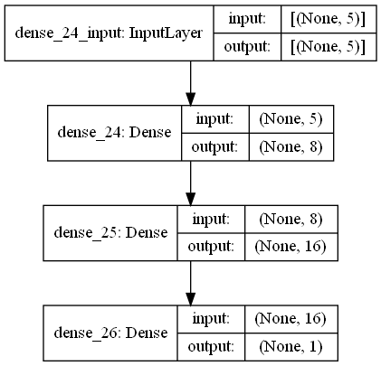

```python
plot_model(model9, to_file='network_regression_model_shapes_9.png', show_shapes=True)
```

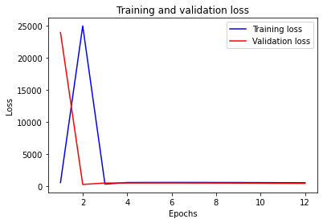

```python
import matplotlib.pyplot as plt
reg_history_dict_9 = reg_history9.history
loss_9 = reg_history_dict_9['loss']
val_loss_9 = reg_history_dict_9['val_loss']

epochs_9 = range(1, len(loss_9) + 1)

plt.plot(epochs_9, loss_9, 'b', label='Training loss')
plt.plot(epochs_9, val_loss_9, label='Validation loss', color='red') # ‘b’는 실선으로, 'bo'는 점으로 나옴
plt.title('Training and validation loss')
plt.xlabel('Epochs')
plt.ylabel('Loss')
plt.legend()

plt.show()
```

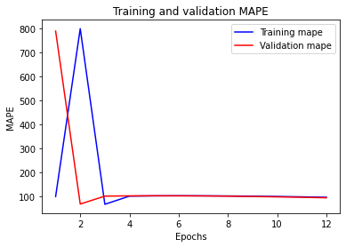

```python
plt.clf() # 그래프를 초기화합니다.
train_metric_9 = reg_history_dict_9['mape']
val_metric_9 = reg_history_dict_9['val_mape']

plt.plot(epochs_9, train_metric_9, 'b', label='Training mape')
plt.plot(epochs_9, val_metric_9, label='Validation mape', color='red')
plt.title('Training and validation MAPE')
plt.xlabel('Epochs')
plt.ylabel('MAPE')
plt.legend()

plt.show()
```

```python
y_pred_9 = model9.predict(test_features)
```

```python
# 성능평가
from sklearn.metrics import r2_score, mean_squared_error, mean_absolute_percentage_error
print('test R squared: %.3f' % r2_score(test_target, y_pred_9))
print('test MSE: %.3f' % mean_squared_error(test_target,y_pred_9))
print('tset MAPE: %.3f' % mean_absolute_percentage_error(test_target,y_pred_9))
```

```
test R squared: -4.486
test MSE: 350.398
tset MAPE: 0.694
```

10) Hidden Layer = 2, Hidden Node = [8,8], learning rate = 1

```python
# Network 구조 형성
import tensorflow as tf
from tensorflow.keras import models
from tensorflow.keras import layers

# tf.set_random_seed(2021) <- 이건 tensorflow 1 version
tf.random.set_seed(2021)

# 1 #
model10 = models.Sequential() # ANN 형성
model10.add(layers.Dense(8, activation = 'relu', input_shape=(train_features.shape[1],)))
model10.add(layers.Dense(8, activation = 'relu', input_shape=(train_features.shape[1],)))
model10.add(layers.Dense(1)) # Output layer - regression은 node가 1개

# 2 #
# loss function과 optimizer 설정
adam = tf.keras.optimizers.Adam(learning_rate=1)

# 3 #
model10.compile(optimizer=adam, loss='mse', metrics=['mape'])

# 콜백 함수 #
es = tf.keras.callbacks.EarlyStopping(monitor='val_loss', patience=10, verbose=1, restore_best_weights=True) # Early stopping
lr = tf.keras.callbacks.ReduceLROnPlateau(monitor='val_loss', factor=0.1, min_lr=0.001) # learning rate 관련


# 4 #
# model.fit(train_data, train_targets, epochs=80, batch_size=16)
reg_history10 = model10.fit(train_features, train_target, epochs=300, batch_size=1024, validation_split=0.2,
                       callbacks=[es,lr])
```

```
Restoring model weights from the end of the best epoch.
Epoch 00053: early stopping
```

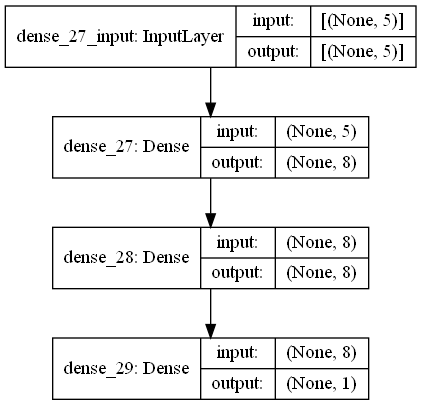

```python
plot_model(model10, to_file='network_regression_model_shapes_10.png', show_shapes=True)
```

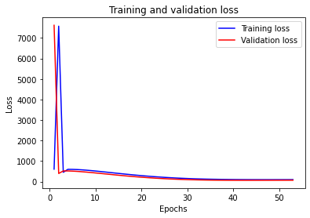

```python
import matplotlib.pyplot as plt
reg_history_dict_10 = reg_history10.history
loss_10 = reg_history_dict_10['loss']
val_loss_10 = reg_history_dict_10['val_loss']

epochs_10 = range(1, len(loss_10) + 1)

plt.plot(epochs_10, loss_10, 'b', label='Training loss')
plt.plot(epochs_10, val_loss_10, label='Validation loss', color='red') # ‘b’는 실선으로, 'bo'는 점으로 나옴
plt.title('Training and validation loss')
plt.xlabel('Epochs')
plt.ylabel('Loss')
plt.legend()

plt.show()
```

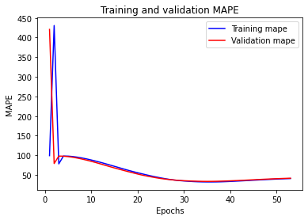

```python
plt.clf() # 그래프를 초기화합니다.
train_metric_10 = reg_history_dict_10['mape']
val_metric_10 = reg_history_dict_10['val_mape']

plt.plot(epochs_10, train_metric_10, 'b', label='Training mape')
plt.plot(epochs_10, val_metric_10, label='Validation mape', color='red')
plt.title('Training and validation MAPE')
plt.xlabel('Epochs')
plt.ylabel('MAPE')
plt.legend()

plt.show()
```

```python
y_pred_10 = model10.predict(test_features)
```

```python
# 성능평가
from sklearn.metrics import r2_score, mean_squared_error, mean_absolute_percentage_error
print('test R squared: %.3f' % r2_score(test_target, y_pred_10))
print('test MSE: %.3f' % mean_squared_error(test_target,y_pred_10))
print('tset MAPE: %.3f' % mean_absolute_percentage_error(test_target,y_pred_10))
```

```
test R squared: -0.008
test MSE: 64.383
tset MAPE: 0.289
```

11) Hidden Layer = 3, Hidden Node = [8,8,8], learning rate = 1

```python
# Network 구조 형성
import tensorflow as tf
from tensorflow.keras import models
from tensorflow.keras import layers

# tf.set_random_seed(2021) <- 이건 tensorflow 1 version
tf.random.set_seed(2021)

# 1 #
model11 = models.Sequential() # ANN 형성
model11.add(layers.Dense(8, activation = 'relu', input_shape=(train_features.shape[1],)))
model11.add(layers.Dense(8, activation = 'relu', input_shape=(train_features.shape[1],)))
model11.add(layers.Dense(8, activation = 'relu', input_shape=(train_features.shape[1],)))
model11.add(layers.Dense(1)) # Output layer - regression은 node가 1개

# 2 #
# loss function과 optimizer 설정
adam = tf.keras.optimizers.Adam(learning_rate=1)

# 3 #
model11.compile(optimizer=adam, loss='mse', metrics=['mape'])

# 콜백 함수 #
es = tf.keras.callbacks.EarlyStopping(monitor='val_loss', patience=10, verbose=1, restore_best_weights=True) # Early stopping
lr = tf.keras.callbacks.ReduceLROnPlateau(monitor='val_loss', factor=0.1, min_lr=0.001) # learning rate 관련


# 4 #
# model.fit(train_data, train_targets, epochs=80, batch_size=16)
reg_history11 = model11.fit(train_features, train_target, epochs=300, batch_size=1024, validation_split=0.2,
                       callbacks=[es,lr])
```

```
Restoring model weights from the end of the best epoch.
Epoch 00012: early stopping
```

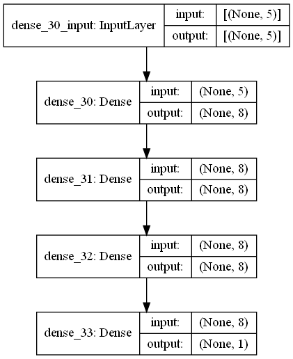

```python
plot_model(model11, to_file='network_regression_model_shapes_11.png', show_shapes=True)
```

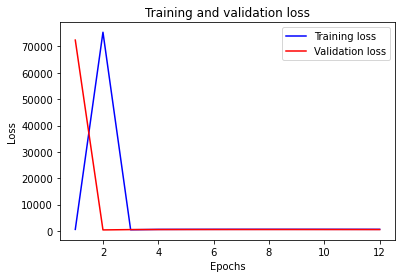

```python
import matplotlib.pyplot as plt
reg_history_dict_11 = reg_history11.history
loss_11 = reg_history_dict_11['loss']
val_loss_11 = reg_history_dict_11['val_loss']

epochs_11 = range(1, len(loss_11) + 1)

plt.plot(epochs_11, loss_11, 'b', label='Training loss')
plt.plot(epochs_11, val_loss_11, label='Validation loss', color='red') # ‘b’는 실선으로, 'bo'는 점으로 나옴
plt.title('Training and validation loss')
plt.xlabel('Epochs')
plt.ylabel('Loss')
plt.legend()

plt.show()
```

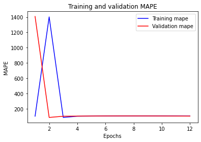

```python
plt.clf() # 그래프를 초기화합니다.
train_metric_11 = reg_history_dict_11['mape']
val_metric_11 = reg_history_dict_11['val_mape']

plt.plot(epochs_11, train_metric_11, 'b', label='Training mape')
plt.plot(epochs_11, val_metric_11, label='Validation mape', color='red')
plt.title('Training and validation MAPE')
plt.xlabel('Epochs')
plt.ylabel('MAPE')
plt.legend()

plt.show()
```

```python
y_pred_11 = model11.predict(test_features)
```

```python
# 성능평가
from sklearn.metrics import r2_score, mean_squared_error, mean_absolute_percentage_error
print('test R squared: %.3f' % r2_score(test_target, y_pred_11))
print('test MSE: %.3f' % mean_squared_error(test_target,y_pred_11))
print('tset MAPE: %.3f' % mean_absolute_percentage_error(test_target,y_pred_11))
```

```
test R squared: -6.089
test MSE: 452.818
tset MAPE: 0.865
```

12) Hidden Layer = 3, Hidden Node = [8,16,8], learning rate = 1

```python
# Network 구조 형성
import tensorflow as tf
from tensorflow.keras import models
from tensorflow.keras import layers

# tf.set_random_seed(2021) <- 이건 tensorflow 1 version
tf.random.set_seed(2021)

# 1 #
model12 = models.Sequential() # ANN 형성
model12.add(layers.Dense(8, activation = 'relu', input_shape=(train_features.shape[1],)))
model12.add(layers.Dense(16, activation = 'relu', input_shape=(train_features.shape[1],)))
model12.add(layers.Dense(8, activation = 'relu', input_shape=(train_features.shape[1],)))
model12.add(layers.Dense(1)) # Output layer - regression은 node가 1개

# 2 #
# loss function과 optimizer 설정
adam = tf.keras.optimizers.Adam(learning_rate=1)

# 3 #
model12.compile(optimizer=adam, loss='mse', metrics=['mape'])

# 콜백 함수 #
es = tf.keras.callbacks.EarlyStopping(monitor='val_loss', patience=10, verbose=1, restore_best_weights=True) # Early stopping
lr = tf.keras.callbacks.ReduceLROnPlateau(monitor='val_loss', factor=0.1, min_lr=0.001) # learning rate 관련


# 4 #
# model.fit(train_data, train_targets, epochs=80, batch_size=16)
reg_history12 = model12.fit(train_features, train_target, epochs=300, batch_size=1024, validation_split=0.2,
                       callbacks=[es,lr])
```

```
Restoring model weights from the end of the best epoch.
Epoch 00012: early stopping
```

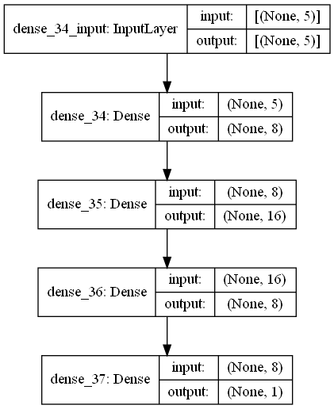

```python
plot_model(model12, to_file='network_regression_model_shapes_12.png', show_shapes=True)
```

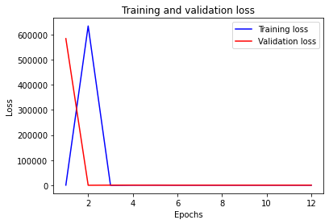

```python
import matplotlib.pyplot as plt
reg_history_dict_12 = reg_history12.history
loss_12 = reg_history_dict_12['loss']
val_loss_12 = reg_history_dict_12['val_loss']

epochs_12 = range(1, len(loss_12) + 1)

plt.plot(epochs_12, loss_12, 'b', label='Training loss')
plt.plot(epochs_12, val_loss_12, label='Validation loss', color='red') # ‘b’는 실선으로, 'bo'는 점으로 나옴
plt.title('Training and validation loss')
plt.xlabel('Epochs')
plt.ylabel('Loss')
plt.legend()

plt.show()
```

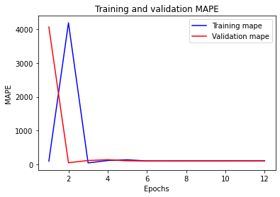

```python
plt.clf() # 그래프를 초기화합니다.
train_metric_12 = reg_history_dict_12['mape']
val_metric_12 = reg_history_dict_12['val_mape']

plt.plot(epochs_12, train_metric_12, 'b', label='Training mape')
plt.plot(epochs_12, val_metric_12, label='Validation mape', color='red')
plt.title('Training and validation MAPE')
plt.xlabel('Epochs')
plt.ylabel('MAPE')
plt.legend()

plt.show()
```

```python
y_pred_12 = model12.predict(test_features)
```

```python
# 성능평가
from sklearn.metrics import r2_score, mean_squared_error, mean_absolute_percentage_error
print('test R squared: %.3f' % r2_score(test_target, y_pred_12))
print('test MSE: %.3f' % mean_squared_error(test_target,y_pred_12))
print('tset MAPE: %.3f' % mean_absolute_percentage_error(test_target,y_pred_12))
```

```
test R squared: -2.150
test MSE: 201.238
tset MAPE: 0.523
```

## Learning Rate = 0.001

13) Hidden Layer = 1, Hidden Node = 8, learning rate = 0.001

```python
# Network 구조 형성
import tensorflow as tf
from tensorflow.keras import models
from tensorflow.keras import layers

# tf.set_random_seed(2021) <- 이건 tensorflow 1 version
tf.random.set_seed(2021)

# 1 #
model13 = models.Sequential() # ANN 형성
model13.add(layers.Dense(8, activation = 'relu', input_shape=(train_features.shape[1],)))
model13.add(layers.Dense(1)) # Output layer - regression은 node가 1개

# 2 #
# loss function과 optimizer 설정
adam = tf.keras.optimizers.Adam(learning_rate=0.001)

# 3 #
model13.compile(optimizer=adam, loss='mse', metrics=['mape'])

# 콜백 함수 #
es = tf.keras.callbacks.EarlyStopping(monitor='val_loss', patience=10, verbose=1, restore_best_weights=True) # Early stopping
lr = tf.keras.callbacks.ReduceLROnPlateau(monitor='val_loss', factor=0.1, min_lr=0.001) # learning rate 관련


# 4 #
# model.fit(train_data, train_targets, epochs=80, batch_size=16)
reg_history13 = model13.fit(train_features, train_target, epochs=6000, batch_size=1024, validation_split=0.2,
                       callbacks=[es,lr])
```

```
Restoring model weights from the end of the best epoch.
Epoch 05419: early stopping
```

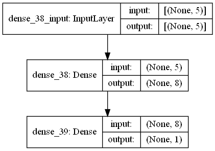

```python
plot_model(model13, to_file='network_regression_model_shapes_13.png', show_shapes=True)
```

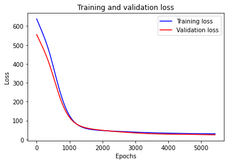

```python
import matplotlib.pyplot as plt
reg_history_dict_13 = reg_history13.history
loss_13 = reg_history_dict_13['loss']
val_loss_13 = reg_history_dict_13['val_loss']

epochs_13 = range(1, len(loss_13) + 1)

plt.plot(epochs_13, loss_13, 'b', label='Training loss')
plt.plot(epochs_13, val_loss_13, label='Validation loss', color='red') # ‘b’는 실선으로, 'bo'는 점으로 나옴
plt.title('Training and validation loss')
plt.xlabel('Epochs')
plt.ylabel('Loss')
plt.legend()

plt.show()
```

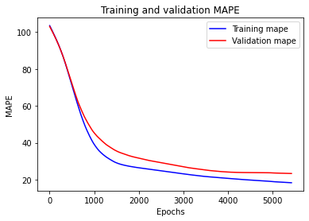

```python
plt.clf() # 그래프를 초기화합니다.
train_metric_13 = reg_history_dict_13['mape']
val_metric_13 = reg_history_dict_13['val_mape']

plt.plot(epochs_13, train_metric_13, 'b', label='Training mape')
plt.plot(epochs_13, val_metric_13, label='Validation mape', color='red')
plt.title('Training and validation MAPE')
plt.xlabel('Epochs')
plt.ylabel('MAPE')
plt.legend()

plt.show()
```

```python
y_pred_13 = model13.predict(test_features)
```

```python
# 성능평가
from sklearn.metrics import r2_score, mean_squared_error, mean_absolute_percentage_error
print('test R squared: %.3f' % r2_score(test_target, y_pred_13))
print('test MSE: %.3f' % mean_squared_error(test_target,y_pred_13))
print('tset MAPE: %.3f' % mean_absolute_percentage_error(test_target,y_pred_13))
```

```
test R squared: 0.626
test MSE: 23.872
tset MAPE: 0.200
```

14) Hidden Layer = 1, Hidden Node = 16, learning rate = 0.001

```python
# Network 구조 형성
import tensorflow as tf
from tensorflow.keras import models
from tensorflow.keras import layers

# tf.set_random_seed(2021) <- 이건 tensorflow 1 version
tf.random.set_seed(2021)

# 1 #
model14 = models.Sequential() # ANN 형성
model14.add(layers.Dense(16, activation = 'relu', input_shape=(train_features.shape[1],)))
model14.add(layers.Dense(1)) # Output layer - regression은 node가 1개

# 2 #
# loss function과 optimizer 설정
adam = tf.keras.optimizers.Adam(learning_rate=0.001)

# 3 #
model14.compile(optimizer=adam, loss='mse', metrics=['mape'])

# 콜백 함수 #
es = tf.keras.callbacks.EarlyStopping(monitor='val_loss', patience=10, verbose=1, restore_best_weights=True) # Early stopping
lr = tf.keras.callbacks.ReduceLROnPlateau(monitor='val_loss', factor=0.1, min_lr=0.001) # learning rate 관련


# 4 #
# model.fit(train_data, train_targets, epochs=80, batch_size=16)
reg_history14 = model14.fit(train_features, train_target, epochs=6000, batch_size=1024, validation_split=0.2,
                       callbacks=[es,lr])
```

[output not shown]

```python
plot_model(model14, to_file='network_regression_model_shapes_14.png', show_shapes=True)
```

[output not shown]

```python
import matplotlib.pyplot as plt
reg_history_dict_14 = reg_history14.history
loss_14 = reg_history_dict_14['loss']
val_loss_14 = reg_history_dict_14['val_loss']

epochs_14 = range(1, len(loss_14) + 1)

plt.plot(epochs_14, loss_14, 'b', label='Training loss')
plt.plot(epochs_14, val_loss_14, label='Validation loss', color='red') # ‘b’는 실선으로, 'bo'는 점으로 나옴
plt.title('Training and validation loss')
plt.xlabel('Epochs')
plt.ylabel('Loss')
plt.legend()

plt.show()
```

[output not shown]

```python
plt.clf() # 그래프를 초기화합니다.
train_metric_14 = reg_history_dict_14['mape']
val_metric_14 = reg_history_dict_14['val_mape']

plt.plot(epochs_14, train_metric_14, 'b', label='Training mape')
plt.plot(epochs_14, val_metric_14, label='Validation mape', color='red')
plt.title('Training and validation MAPE')
plt.xlabel('Epochs')
plt.ylabel('MAPE')
plt.legend()

plt.show()
```

[output not shown]

```python
y_pred_14 = model14.predict(test_features)
```

```python
# 성능평가
from sklearn.metrics import r2_score, mean_squared_error, mean_absolute_percentage_error
print('test R squared: %.3f' % r2_score(test_target, y_pred_14))
print('test MSE: %.3f' % mean_squared_error(test_target,y_pred_14))
print('tset MAPE: %.3f' % mean_absolute_percentage_error(test_target,y_pred_14))
```

[output not shown]

15) Hidden Layer = 2, Hidden Node = [8,16], learning rate = 0.001

```python
# Network 구조 형성
import tensorflow as tf
from tensorflow.keras import models
from tensorflow.keras import layers

# tf.set_random_seed(2021) <- 이건 tensorflow 1 version
tf.random.set_seed(2021)

# 1 #
model15 = models.Sequential() # ANN 형성
model15.add(layers.Dense(8, activation = 'relu', input_shape=(train_features.shape[1],)))
model15.add(layers.Dense(16, activation = 'relu', input_shape=(train_features.shape[1],)))
model15.add(layers.Dense(1)) # Output layer - regression은 node가 1개

# 2 #
# loss function과 optimizer 설정
adam = tf.keras.optimizers.Adam(learning_rate=0.001)

# 3 #
model15.compile(optimizer=adam, loss='mse', metrics=['mape'])

# 콜백 함수 #
es = tf.keras.callbacks.EarlyStopping(monitor='val_loss', patience=10, verbose=1, restore_best_weights=True) # Early stopping
lr = tf.keras.callbacks.ReduceLROnPlateau(monitor='val_loss', factor=0.1, min_lr=0.001) # learning rate 관련


# 4 #
# model.fit(train_data, train_targets, epochs=80, batch_size=16)
reg_history15 = model15.fit(train_features, train_target, epochs=6000, batch_size=1024, validation_split=0.2,
                       callbacks=[es,lr])
```

```
Restoring model weights from the end of the best epoch.
Epoch 02644: early stopping
```

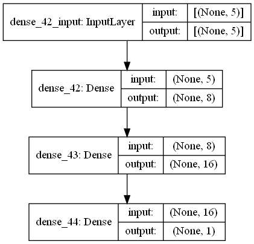

```python
plot_model(model15, to_file='network_regression_model_shapes_15.png', show_shapes=True)
```

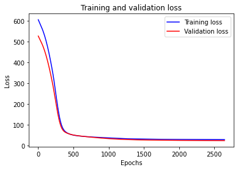

```python
import matplotlib.pyplot as plt
reg_history_dict_15 = reg_history15.history
loss_15 = reg_history_dict_15['loss']
val_loss_15 = reg_history_dict_15['val_loss']

epochs_15 = range(1, len(loss_15) + 1)

plt.plot(epochs_15, loss_15, 'b', label='Training loss')
plt.plot(epochs_15, val_loss_15, label='Validation loss', color='red') # ‘b’는 실선으로, 'bo'는 점으로 나옴
plt.title('Training and validation loss')
plt.xlabel('Epochs')
plt.ylabel('Loss')
plt.legend()

plt.show()
```

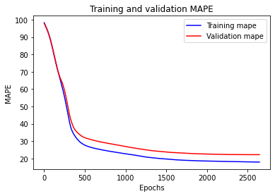

```python
plt.clf() # 그래프를 초기화합니다.
train_metric_15 = reg_history_dict_15['mape']
val_metric_15 = reg_history_dict_15['val_mape']

plt.plot(epochs_15, train_metric_15, 'b', label='Training mape')
plt.plot(epochs_15, val_metric_15, label='Validation mape', color='red')
plt.title('Training and validation MAPE')
plt.xlabel('Epochs')
plt.ylabel('MAPE')
plt.legend()

plt.show()
```

```python
y_pred_15 = model15.predict(test_features)
```

```python
# 성능평가
from sklearn.metrics import r2_score, mean_squared_error, mean_absolute_percentage_error
print('test R squared: %.3f' % r2_score(test_target, y_pred_15))
print('test MSE: %.3f' % mean_squared_error(test_target,y_pred_15))
print('tset MAPE: %.3f' % mean_absolute_percentage_error(test_target,y_pred_15))
```

```
test R squared: 0.504
test MSE: 31.697
tset MAPE: 0.209
```

16) Hidden Layer = 2, Hidden Node = [8,8], learning rate = 0.001

```python
# Network 구조 형성
import tensorflow as tf
from tensorflow.keras import models
from tensorflow.keras import layers

# tf.set_random_seed(2021) <- 이건 tensorflow 1 version
tf.random.set_seed(2021)

# 1 #
model16 = models.Sequential() # ANN 형성
model16.add(layers.Dense(8, activation = 'relu', input_shape=(train_features.shape[1],)))
model16.add(layers.Dense(8, activation = 'relu', input_shape=(train_features.shape[1],)))
model16.add(layers.Dense(1)) # Output layer - regression은 node가 1개

# 2 #
# loss function과 optimizer 설정
adam = tf.keras.optimizers.Adam(learning_rate=0.001)

# 3 #
model16.compile(optimizer=adam, loss='mse', metrics=['mape'])

# 콜백 함수 #
es = tf.keras.callbacks.EarlyStopping(monitor='val_loss', patience=10, verbose=1, restore_best_weights=True) # Early stopping
lr = tf.keras.callbacks.ReduceLROnPlateau(monitor='val_loss', factor=0.1, min_lr=0.001) # learning rate 관련


# 4 #
# model.fit(train_data, train_targets, epochs=80, batch_size=16)
reg_history16 = model16.fit(train_features, train_target, epochs=6000, batch_size=1024, validation_split=0.2,
                       callbacks=[es,lr])
```

```
Restoring model weights from the end of the best epoch.
Epoch 02540: early stopping
```

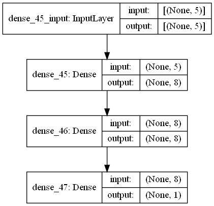

```python
plot_model(model16, to_file='network_regression_model_shapes_16.png', show_shapes=True)
```

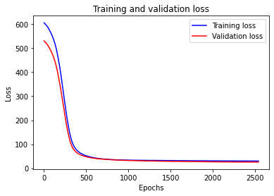

```python
import matplotlib.pyplot as plt
reg_history_dict_16 = reg_history16.history
loss_16 = reg_history_dict_16['loss']
val_loss_16 = reg_history_dict_16['val_loss']

epochs_16 = range(1, len(loss_16) + 1)

plt.plot(epochs_16, loss_16, 'b', label='Training loss')
plt.plot(epochs_16, val_loss_16, label='Validation loss', color='red') # ‘b’는 실선으로, 'bo'는 점으로 나옴
plt.title('Training and validation loss')
plt.xlabel('Epochs')
plt.ylabel('Loss')
plt.legend()

plt.show()
```

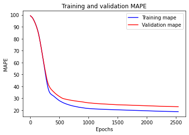

```python
plt.clf() # 그래프를 초기화합니다.
train_metric_16 = reg_history_dict_16['mape']
val_metric_16 = reg_history_dict_16['val_mape']

plt.plot(epochs_16, train_metric_16, 'b', label='Training mape')
plt.plot(epochs_16, val_metric_16, label='Validation mape', color='red')
plt.title('Training and validation MAPE')
plt.xlabel('Epochs')
plt.ylabel('MAPE')
plt.legend()

plt.show()
```

```python
y_pred_16 = model16.predict(test_features)
```

```python
# 성능평가
from sklearn.metrics import r2_score, mean_squared_error, mean_absolute_percentage_error
print('test R squared: %.3f' % r2_score(test_target, y_pred_16))
print('test MSE: %.3f' % mean_squared_error(test_target,y_pred_16))
print('tset MAPE: %.3f' % mean_absolute_percentage_error(test_target,y_pred_16))
```

```
test R squared: 0.557
test MSE: 28.295
tset MAPE: 0.209
```

17) Hidden Layer = 3, Hidden Node = [8,8,8], learning rate = 0.001

```python
# Network 구조 형성
import tensorflow as tf
from tensorflow.keras import models
from tensorflow.keras import layers

# tf.set_random_seed(2021) <- 이건 tensorflow 1 version
tf.random.set_seed(2021)

# 1 #
model17 = models.Sequential() # ANN 형성
model17.add(layers.Dense(8, activation = 'relu', input_shape=(train_features.shape[1],)))
model17.add(layers.Dense(8, activation = 'relu', input_shape=(train_features.shape[1],)))
model17.add(layers.Dense(8, activation = 'relu', input_shape=(train_features.shape[1],)))
model17.add(layers.Dense(1)) # Output layer - regression은 node가 1개

# 2 #
# loss function과 optimizer 설정
adam = tf.keras.optimizers.Adam(learning_rate=0.001)

# 3 #
model17.compile(optimizer=adam, loss='mse', metrics=['mape'])

# 콜백 함수 #
es = tf.keras.callbacks.EarlyStopping(monitor='val_loss', patience=10, verbose=1, restore_best_weights=True) # Early stopping
lr = tf.keras.callbacks.ReduceLROnPlateau(monitor='val_loss', factor=0.1, min_lr=0.001) # learning rate 관련


# 4 #
# model.fit(train_data, train_targets, epochs=80, batch_size=16)
reg_history17 = model17.fit(train_features, train_target, epochs=6000, batch_size=1024, validation_split=0.2,
                       callbacks=[es,lr])
```

```
Restoring model weights from the end of the best epoch.
Epoch 02036: early stopping
```

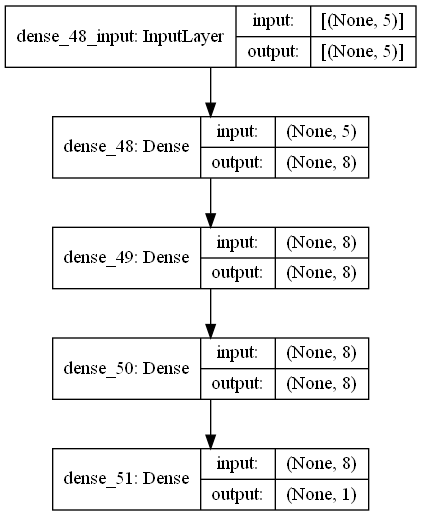

```python
plot_model(model17, to_file='network_regression_model_shapes_17.png', show_shapes=True)
```

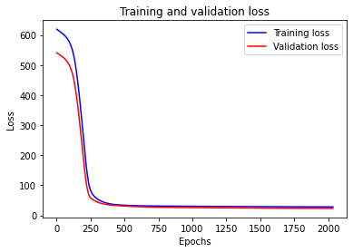

```python
import matplotlib.pyplot as plt
reg_history_dict_17 = reg_history17.history
loss_17 = reg_history_dict_17['loss']
val_loss_17 = reg_history_dict_17['val_loss']

epochs_17 = range(1, len(loss_17) + 1)

plt.plot(epochs_17, loss_17, 'b', label='Training loss')
plt.plot(epochs_17, val_loss_17, label='Validation loss', color='red') # ‘b’는 실선으로, 'bo'는 점으로 나옴
plt.title('Training and validation loss')
plt.xlabel('Epochs')
plt.ylabel('Loss')
plt.legend()

plt.show()
```

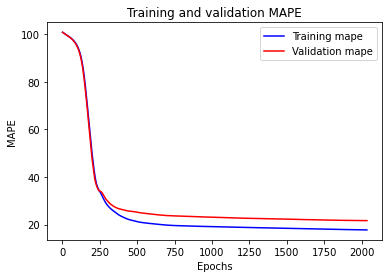

```python
plt.clf() # 그래프를 초기화합니다.
train_metric_17 = reg_history_dict_17['mape']
val_metric_17 = reg_history_dict_17['val_mape']

plt.plot(epochs_17, train_metric_17, 'b', label='Training mape')
plt.plot(epochs_17, val_metric_17, label='Validation mape', color='red')
plt.title('Training and validation MAPE')
plt.xlabel('Epochs')
plt.ylabel('MAPE')
plt.legend()

plt.show()
```

```python
y_pred_17 = model17.predict(test_features)
```

```python
# 성능평가
from sklearn.metrics import r2_score, mean_squared_error, mean_absolute_percentage_error
print('test R squared: %.3f' % r2_score(test_target, y_pred_17))
print('test MSE: %.3f' % mean_squared_error(test_target,y_pred_17))
print('tset MAPE: %.3f' % mean_absolute_percentage_error(test_target,y_pred_17))
```

```
test R squared: 0.537
test MSE: 29.562
tset MAPE: 0.202
```

18) Hidden Layer = 3, Hidden Node = [8,16,8], learning rate = 0.001

```python
# Network 구조 형성
import tensorflow as tf
from tensorflow.keras import models
from tensorflow.keras import layers

# tf.set_random_seed(2021) <- 이건 tensorflow 1 version
tf.random.set_seed(2021)

# 1 #
model18 = models.Sequential() # ANN 형성
model18.add(layers.Dense(8, activation = 'relu', input_shape=(train_features.shape[1],)))
model18.add(layers.Dense(16, activation = 'relu', input_shape=(train_features.shape[1],)))
model18.add(layers.Dense(8, activation = 'relu', input_shape=(train_features.shape[1],)))
model18.add(layers.Dense(1)) # Output layer - regression은 node가 1개

# 2 #
# loss function과 optimizer 설정
adam = tf.keras.optimizers.Adam(learning_rate=0.001)

# 3 #
model18.compile(optimizer=adam, loss='mse', metrics=['mape'])

# 콜백 함수 #
es = tf.keras.callbacks.EarlyStopping(monitor='val_loss', patience=10, verbose=1, restore_best_weights=True) # Early stopping
lr = tf.keras.callbacks.ReduceLROnPlateau(monitor='val_loss', factor=0.1, min_lr=0.001) # learning rate 관련


# 4 #
# model.fit(train_data, train_targets, epochs=80, batch_size=16)
reg_history18 = model18.fit(train_features, train_target, epochs=6000, batch_size=1024, validation_split=0.2,
                       callbacks=[es,lr])
```

```
Restoring model weights from the end of the best epoch.
Epoch 01396: early stopping
```

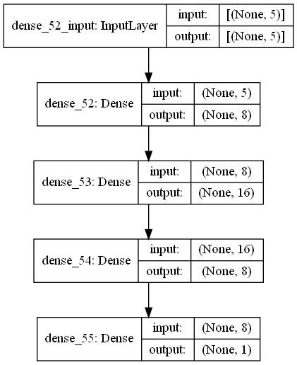

```python
plot_model(model18, to_file='network_regression_model_shapes_18.png', show_shapes=True)
```

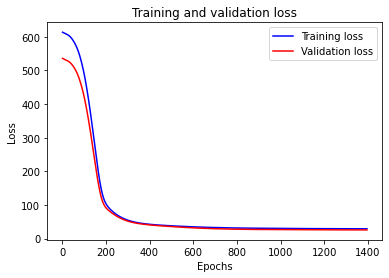

```python
import matplotlib.pyplot as plt
reg_history_dict_18 = reg_history18.history
loss_18 = reg_history_dict_18['loss']
val_loss_18 = reg_history_dict_18['val_loss']

epochs_18 = range(1, len(loss_18) + 1)

plt.plot(epochs_18, loss_18, 'b', label='Training loss')
plt.plot(epochs_18, val_loss_18, label='Validation loss', color='red') # ‘b’는 실선으로, 'bo'는 점으로 나옴
plt.title('Training and validation loss')
plt.xlabel('Epochs')
plt.ylabel('Loss')
plt.legend()

plt.show()
```

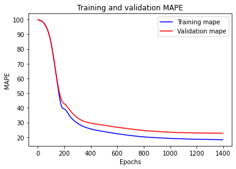

```python
plt.clf() # 그래프를 초기화합니다.
train_metric_18 = reg_history_dict_18['mape']
val_metric_18 = reg_history_dict_18['val_mape']

plt.plot(epochs_18, train_metric_18, 'b', label='Training mape')
plt.plot(epochs_18, val_metric_18, label='Validation mape', color='red')
plt.title('Training and validation MAPE')
plt.xlabel('Epochs')
plt.ylabel('MAPE')
plt.legend()

plt.show()
```

```python
y_pred_18 = model18.predict(test_features)
```

```python
# 성능평가
from sklearn.metrics import r2_score, mean_squared_error, mean_absolute_percentage_error
print('test R squared: %.3f' % r2_score(test_target, y_pred_18))
print('test MSE: %.3f' % mean_squared_error(test_target,y_pred_18))
print('tset MAPE: %.3f' % mean_absolute_percentage_error(test_target,y_pred_18))
```

```
test R squared: 0.525
test MSE: 30.328
tset MAPE: 0.211
```

### 7번의 Weight & Bias

```python
pd.DataFrame(model7.get_weights()[0])
```

|  | 0 | 1 | 2 | 3 | 4 | 5 | 6 | 7 |
| --- | --- | --- | --- | --- | --- | --- | --- | --- |
| 0 | -2.076026 | -1.257015 | -2.162390 | 0.150514 | -0.983251 | 4.988212 | 0.495522 | -6.974717 |
| 1 | 0.818258 | 2.034670 | 3.164726 | 3.963000 | 0.814939 | 0.863415 | 0.562755 | -2.369919 |
| 2 | 0.048568 | -1.759760 | -2.756717 | 0.819765 | -0.481640 | 1.350500 | 1.186973 | 1.649738 |
| 3 | -3.151246 | -3.861568 | -2.760843 | -2.327465 | -2.136896 | 5.571667 | -0.474956 | -3.843774 |
| 4 | 0.645698 | -0.927398 | 2.925219 | -2.631753 | 0.570735 | -2.487990 | -2.985180 | -0.414323 |

```python
pd.DataFrame(model7.get_weights()[1])
```

|  | 0 |
| --- | --- |
| 0 | 0.209647 |
| 1 | 5.810978 |
| 2 | -7.020473 |
| 3 | 2.905868 |
| 4 | -7.248552 |
| 5 | -5.821320 |
| 6 | -5.846183 |
| 7 | -6.285237 |

```python
pd.DataFrame(model7.get_weights()[2])
```

|  | 0 |
| --- | --- |
| 0 | -0.845443 |
| 1 | 1.698254 |
| 2 | 0.494322 |
| 3 | 0.894611 |
| 4 | -2.506837 |
| 5 | 0.632257 |
| 6 | -1.227212 |
| 7 | -0.524946 |

```python
pd.DataFrame(model7.get_weights()[3])
```

|  | 0 |
| --- | --- |
| 0 | 7.255847 |

### 4번의 Weight & Bias

```python
pd.DataFrame(model4.get_weights()[0])
```

|  | 0 | 1 | 2 | 3 | 4 | 5 | 6 | 7 |
| --- | --- | --- | --- | --- | --- | --- | --- | --- |
| 0 | -0.039038 | -0.455208 | -0.406142 | -0.288250 | 0.843704 | 0.250859 | 0.496823 | 0.881753 |
| 1 | 0.838305 | -0.287277 | 1.546144 | 1.176397 | 0.770432 | -0.340828 | 0.300017 | 1.604448 |
| 2 | 1.069781 | 0.900096 | -1.101443 | 0.193824 | -1.100886 | 0.700490 | 0.442154 | -0.222563 |
| 3 | 0.794881 | -1.006123 | -1.459158 | -0.127685 | 0.375017 | -0.321612 | 0.756707 | 0.032858 |
| 4 | -0.370277 | -1.083206 | 0.155144 | -1.141891 | -0.285181 | -0.158653 | -1.006827 | -0.265214 |

```python
pd.DataFrame(model4.get_weights()[1])
```

|  | 0 |
| --- | --- |
| 0 | -1.009969 |
| 1 | 0.438002 |
| 2 | 1.704736 |
| 3 | 1.314862 |
| 4 | 0.483658 |
| 5 | -0.047016 |
| 6 | 0.806499 |
| 7 | -0.690030 |

```python
pd.DataFrame(model4.get_weights()[2])
```

|  | 0 | 1 | 2 | 3 | 4 | 5 | 6 | 7 |
| --- | --- | --- | --- | --- | --- | --- | --- | --- |
| 0 | -0.245803 | -0.083933 | -0.052625 | -0.207364 | -0.491055 | -0.958419 | -1.232579 | -0.764919 |
| 1 | 0.055686 | 0.002670 | 0.764659 | 0.639386 | 0.655830 | -0.173753 | -0.339840 | 0.107941 |
| 2 | 1.067103 | -1.021964 | 0.346460 | 1.110923 | 0.302275 | -0.757555 | -0.850223 | 0.381303 |
| 3 | 0.380439 | -0.374367 | 0.835392 | 0.446694 | 0.081748 | -0.550155 | -0.262079 | 0.276154 |
| 4 | 0.164344 | -0.623512 | 0.712410 | 0.928830 | -0.274459 | -0.754092 | -1.150865 | 0.754098 |
| 5 | 0.067644 | -1.155041 | -0.552222 | -0.608980 | 0.398700 | -0.565496 | -0.319838 | -0.174647 |
| 6 | -0.460427 | -1.018174 | 0.835995 | -0.203154 | 0.312613 | -1.116944 | -1.281312 | 0.780050 |
| 7 | 0.250554 | -0.390412 | 0.221312 | 0.336706 | 0.364109 | -0.400656 | -0.836734 | 0.239570 |

```python
pd.DataFrame(model4.get_weights()[3])
```

|  | 0 |
| --- | --- |
| 0 | 1.788986 |
| 1 | -0.599411 |
| 2 | 1.813778 |
| 3 | 1.904248 |
| 4 | 1.645380 |
| 5 | -0.626305 |
| 6 | -0.750839 |
| 7 | 1.683008 |

```python
pd.DataFrame(model4.get_weights()[4])
```

|  | 0 |
| --- | --- |
| 0 | 0.891077 |
| 1 | 0.363826 |
| 2 | 0.843122 |
| 3 | 0.861813 |
| 4 | 0.616850 |
| 5 | -0.124935 |
| 6 | -0.074764 |
| 7 | 0.910673 |

```python
pd.DataFrame(model4.get_weights()[5])
```

|  | 0 |
| --- | --- |
| 0 | 1.681129 |

## 7번 모델에 대한 정보

```python
#reg_history_dict = reg_history.history
reg_history_dict_7.keys()
```

```
dict_keys(['loss', 'mape', 'val_loss', 'val_mape', 'lr'])
```

```python
reg_history7.history
```

[output not shown]

[output cut: 90 more lines]

[output not shown]

```python
from sklearn.metrics import r2_score, mean_squared_error, mean_absolute_percentage_error
print('test R squared: %.3f' % r2_score(test_target, y_pred_7))
print('test MSE: %.3f' % mean_squared_error(test_target,y_pred_7))
print('tset MAPE: %.3f' % mean_absolute_percentage_error(test_target,y_pred_7))
```

```
test R squared: 0.634
test MSE: 23.381
tset MAPE: 0.197
```

```python
model3.summary()
```

```
Model: "sequential_3"
_________________________________________________________________
Layer (type)                 Output Shape              Param #
=================================================================
dense_6 (Dense)              (None, 8)                 48
_________________________________________________________________
dense_7 (Dense)              (None, 16)                144
_________________________________________________________________
dense_8 (Dense)              (None, 1)                 17
=================================================================
Total params: 209
Trainable params: 209
Non-trainable params: 0
_________________________________________________________________
```

```python
model4.summary()
```

```
Model: "sequential_4"
_________________________________________________________________
Layer (type)                 Output Shape              Param #
=================================================================
dense_9 (Dense)              (None, 8)                 48
_________________________________________________________________
dense_10 (Dense)             (None, 8)                 72
_________________________________________________________________
dense_11 (Dense)             (None, 1)                 9
=================================================================
Total params: 129
Trainable params: 129
Non-trainable params: 0
_________________________________________________________________
```

```python
model5.summary()
```

```
Model: "sequential_5"
_________________________________________________________________
Layer (type)                 Output Shape              Param #
=================================================================
dense_12 (Dense)             (None, 8)                 48
_________________________________________________________________
dense_13 (Dense)             (None, 8)                 72
_________________________________________________________________
dense_14 (Dense)             (None, 8)                 72
_________________________________________________________________
dense_15 (Dense)             (None, 1)                 9
=================================================================
Total params: 201
Trainable params: 201
Non-trainable params: 0
_________________________________________________________________
```

```python
model6.summary()
```

```
Model: "sequential_6"
_________________________________________________________________
Layer (type)                 Output Shape              Param #
=================================================================
dense_16 (Dense)             (None, 8)                 48
_________________________________________________________________
dense_17 (Dense)             (None, 16)                144
_________________________________________________________________
dense_18 (Dense)             (None, 8)                 136
_________________________________________________________________
dense_19 (Dense)             (None, 1)                 9
=================================================================
Total params: 337
Trainable params: 337
Non-trainable params: 0
_________________________________________________________________
```

```python
model7.summary()
```

```
Model: "sequential_7"
_________________________________________________________________
Layer (type)                 Output Shape              Param #
=================================================================
dense_20 (Dense)             (None, 8)                 48
_________________________________________________________________
dense_21 (Dense)             (None, 1)                 9
=================================================================
Total params: 57
Trainable params: 57
Non-trainable params: 0
_________________________________________________________________
```

```python
model8.summary()
```

```
Model: "sequential_8"
_________________________________________________________________
Layer (type)                 Output Shape              Param #
=================================================================
dense_22 (Dense)             (None, 16)                96
_________________________________________________________________
dense_23 (Dense)             (None, 1)                 17
=================================================================
Total params: 113
Trainable params: 113
Non-trainable params: 0
_________________________________________________________________
```

```python
model9.summary()
```

```
Model: "sequential_9"
_________________________________________________________________
Layer (type)                 Output Shape              Param #
=================================================================
dense_24 (Dense)             (None, 8)                 48
_________________________________________________________________
dense_25 (Dense)             (None, 16)                144
_________________________________________________________________
dense_26 (Dense)             (None, 1)                 17
=================================================================
Total params: 209
Trainable params: 209
Non-trainable params: 0
_________________________________________________________________
```

```python
model10.summary()
```

```
Model: "sequential_10"
_________________________________________________________________
Layer (type)                 Output Shape              Param #
=================================================================
dense_27 (Dense)             (None, 8)                 48
_________________________________________________________________
dense_28 (Dense)             (None, 8)                 72
_________________________________________________________________
dense_29 (Dense)             (None, 1)                 9
=================================================================
Total params: 129
Trainable params: 129
Non-trainable params: 0
_________________________________________________________________
```

```python
model11.summary()
```

```
Model: "sequential_11"
_________________________________________________________________
Layer (type)                 Output Shape              Param #
=================================================================
dense_30 (Dense)             (None, 8)                 48
_________________________________________________________________
dense_31 (Dense)             (None, 8)                 72
_________________________________________________________________
dense_32 (Dense)             (None, 8)                 72
_________________________________________________________________
dense_33 (Dense)             (None, 1)                 9
=================================================================
Total params: 201
Trainable params: 201
Non-trainable params: 0
_________________________________________________________________
```

```python
model12.summary()
```

```
Model: "sequential_12"
_________________________________________________________________
Layer (type)                 Output Shape              Param #
=================================================================
dense_34 (Dense)             (None, 8)                 48
_________________________________________________________________
dense_35 (Dense)             (None, 16)                144
_________________________________________________________________
dense_36 (Dense)             (None, 8)                 136
_________________________________________________________________
dense_37 (Dense)             (None, 1)                 9
=================================================================
Total params: 337
Trainable params: 337
Non-trainable params: 0
_________________________________________________________________
```

```python
model13.summary()
```

```
Model: "sequential_13"
_________________________________________________________________
Layer (type)                 Output Shape              Param #
=================================================================
dense_38 (Dense)             (None, 8)                 48
_________________________________________________________________
dense_39 (Dense)             (None, 1)                 9
=================================================================
Total params: 57
Trainable params: 57
Non-trainable params: 0
_________________________________________________________________
```

```python
model14.summary()
```

```
Model: "sequential_14"
_________________________________________________________________
Layer (type)                 Output Shape              Param #
=================================================================
dense_40 (Dense)             (None, 16)                96
_________________________________________________________________
dense_41 (Dense)             (None, 1)                 17
=================================================================
Total params: 113
Trainable params: 113
Non-trainable params: 0
_________________________________________________________________
```

```python
model15.summary()
```

```
Model: "sequential_15"
_________________________________________________________________
Layer (type)                 Output Shape              Param #
=================================================================
dense_42 (Dense)             (None, 8)                 48
_________________________________________________________________
dense_43 (Dense)             (None, 16)                144
_________________________________________________________________
dense_44 (Dense)             (None, 1)                 17
=================================================================
Total params: 209
Trainable params: 209
Non-trainable params: 0
_________________________________________________________________
```

```python
model16.summary()
```

```
Model: "sequential_16"
_________________________________________________________________
Layer (type)                 Output Shape              Param #
=================================================================
dense_45 (Dense)             (None, 8)                 48
_________________________________________________________________
dense_46 (Dense)             (None, 8)                 72
_________________________________________________________________
dense_47 (Dense)             (None, 1)                 9
=================================================================
Total params: 129
Trainable params: 129
Non-trainable params: 0
_________________________________________________________________
```

```python
model17.summary()
```

```
Model: "sequential_17"
_________________________________________________________________
Layer (type)                 Output Shape              Param #
=================================================================
dense_48 (Dense)             (None, 8)                 48
_________________________________________________________________
dense_49 (Dense)             (None, 8)                 72
_________________________________________________________________
dense_50 (Dense)             (None, 8)                 72
_________________________________________________________________
dense_51 (Dense)             (None, 1)                 9
=================================================================
Total params: 201
Trainable params: 201
Non-trainable params: 0
_________________________________________________________________
```

```python
model18.summary()
```

```
Model: "sequential_18"
_________________________________________________________________
Layer (type)                 Output Shape              Param #
=================================================================
dense_52 (Dense)             (None, 8)                 48
_________________________________________________________________
dense_53 (Dense)             (None, 16)                144
_________________________________________________________________
dense_54 (Dense)             (None, 8)                 136
_________________________________________________________________
dense_55 (Dense)             (None, 1)                 9
=================================================================
Total params: 337
Trainable params: 337
Non-trainable params: 0
_________________________________________________________________
```

# 성능평가 시각화

```python
import pandas as pd
import numpy as np
from pandas import DataFrame as df
#from matplotlib import pyplot
import matplotlib as mpl
import matplotlib.pyplot as plt
import matplotlib.font_manager as fm
mpl.rcParams['axes.unicode_minus'] = False
```

```python
performance = df(data={'R_squared': [0.578, 0.583, 0.565, 0.607, 0.593, 0.585, 0.634, 0.372, -4.486,
                                     -0.008,-6.089, -2.150, 0.626, 0.624, 0.504, 0.557, 0.537, 0.525],
                        'MSE': [26.930, 26.630, 27.767, 25.080, 26.018, 26.480, 23.381, 40.122, 350.398,
                               64.383, 452.818, 201.238, 23.872, 24.000, 31.697, 28.295, 29.562, 30.328],
                        'MAPE': [0.220, 0.221, 0.225, 0.205, 0.202, 0.222, 0.197, 0.276, 0.694, 0.289,
                                0.865, 0.523, 0.200, 0.197, 0.209, 0.209, 0.202, 0.211]},
                index=['1', '2', '3', '4', '5', '6', '7', '8', '9',
                       '10', '11', '12', '13', '14', '15', '16', '17', '18'])
```

```python
performance
```

|  | R_squared | MSE | MAPE |
| --- | --- | --- | --- |
| 1 | 0.578 | 26.930 | 0.220 |
| 2 | 0.583 | 26.630 | 0.221 |
| 3 | 0.565 | 27.767 | 0.225 |
| 4 | 0.607 | 25.080 | 0.205 |
| 5 | 0.593 | 26.018 | 0.202 |
| 6 | 0.585 | 26.480 | 0.222 |
| 7 | 0.634 | 23.381 | 0.197 |
| 8 | 0.372 | 40.122 | 0.276 |
| 9 | -4.486 | 350.398 | 0.694 |
| 10 | -0.008 | 64.383 | 0.289 |
| 11 | -6.089 | 452.818 | 0.865 |
| 12 | -2.150 | 201.238 | 0.523 |
| 13 | 0.626 | 23.872 | 0.200 |
| 14 | 0.624 | 24.000 | 0.197 |
| 15 | 0.504 | 31.697 | 0.209 |
| 16 | 0.557 | 28.295 | 0.209 |
| 17 | 0.537 | 29.562 | 0.202 |
| 18 | 0.525 | 30.328 | 0.211 |

```python
performance_1layer = performance.loc[['1', '2', '7', '8', '13', '14'],:]
performance_2layer = performance.loc[['3', '4', '9', '10', '15', '16'],:]
performance_3layer = performance.loc[['5', '6', '11', '12', '17', '18'],:]
index_1layer = ['1', '2', '7', '8', '13', '14']
index_2layer = ['3', '4', '9', '10', '15', '16']
index_3layer = ['5', '6', '11', '12', '17', '18']
```

## 1layer끼리 비교

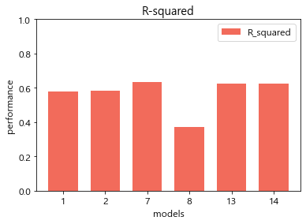

```python
%matplotlib inline

R_squared = performance_1layer['R_squared']

plt.rcParams['font.family'] = 'Malgun Gothic'
plt.rcParams['font.size'] = 12

plt.figure()

x = np.arange(len(index_1layer))

plt.bar(x-0.0, R_squared, label='R_squared', width=0.7, color='#f26b5b')
plt.xticks(x, index_1layer)

plt.legend()
plt.xlabel('models')
plt.ylabel('performance')
plt.ylim(0, 1)
plt.title('R-squared')

plt.show()

plt.close()
```

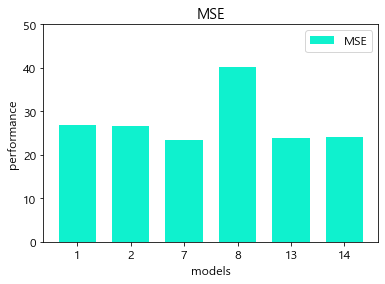

```python
%matplotlib inline

MSE = performance_1layer['MSE']

plt.rcParams['font.family'] = 'Malgun Gothic'
plt.rcParams['font.size'] = 12

plt.figure()

x = np.arange(len(index_1layer))

plt.bar(x-0.0, MSE, label='MSE', width=0.7, color='#0ff1ce')
plt.xticks(x, index_1layer)

plt.legend()
plt.xlabel('models')
plt.ylabel('performance')
plt.ylim(0, 50)
plt.title('MSE')

plt.show()

plt.close()
```

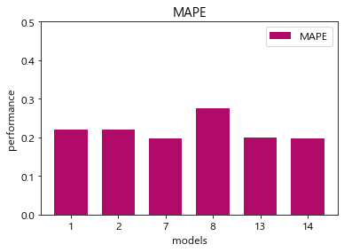

```python
%matplotlib inline

MAPE = performance_1layer['MAPE']

plt.rcParams['font.family'] = 'Malgun Gothic'
plt.rcParams['font.size'] = 12

plt.figure()

x = np.arange(len(index_1layer))

plt.bar(x-0.0, MAPE, label='MAPE', width=0.7, color='#b00b69')
plt.xticks(x, index_1layer)

plt.legend()
plt.xlabel('models')
plt.ylabel('performance')
plt.ylim(0, 0.5)
plt.title('MAPE')

plt.show()

plt.close()
```

## 2layer끼리 비교

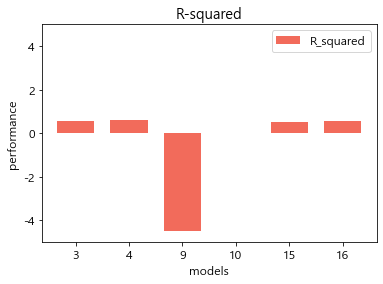

```python
%matplotlib inline

R_squared = performance_2layer['R_squared']

plt.rcParams['font.family'] = 'Malgun Gothic'
plt.rcParams['font.size'] = 12

plt.figure()

x = np.arange(len(index_2layer))

plt.bar(x-0.0, R_squared, label='R_squared', width=0.7, color='#f26b5b')
plt.xticks(x, index_2layer)

plt.legend()
plt.xlabel('models')
plt.ylabel('performance')
plt.ylim(-5, 5)
plt.title('R-squared')

plt.show()

plt.close()
```

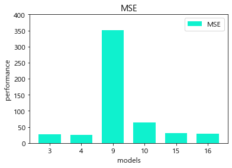

```python
%matplotlib inline

MSE = performance_2layer['MSE']

plt.rcParams['font.family'] = 'Malgun Gothic'
plt.rcParams['font.size'] = 12

plt.figure()

x = np.arange(len(index_2layer))

plt.bar(x-0.0, MSE, label='MSE', width=0.7, color='#0ff1ce')
plt.xticks(x, index_2layer)

plt.legend()
plt.xlabel('models')
plt.ylabel('performance')
plt.ylim(0, 400)
plt.title('MSE')

plt.show()

plt.close()
```

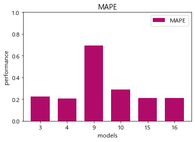

```python
%matplotlib inline

MAPE = performance_2layer['MAPE']

plt.rcParams['font.family'] = 'Malgun Gothic'
plt.rcParams['font.size'] = 12

plt.figure()

x = np.arange(len(index_2layer))

plt.bar(x-0.0, MAPE, label='MAPE', width=0.7, color='#b00b69')
plt.xticks(x, index_2layer)

plt.legend()
plt.xlabel('models')
plt.ylabel('performance')
plt.ylim(0, 1)
plt.title('MAPE')

plt.show()

plt.close()
```

## 3layer끼리 비교

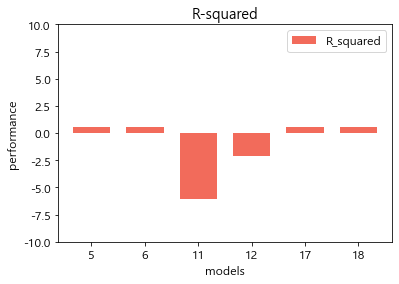

```python
%matplotlib inline

R_squared = performance_3layer['R_squared']

plt.rcParams['font.family'] = 'Malgun Gothic'
plt.rcParams['font.size'] = 12

plt.figure()

x = np.arange(len(index_3layer))

plt.bar(x-0.0, R_squared, label='R_squared', width=0.7, color='#f26b5b')
plt.xticks(x, index_3layer)

plt.legend()
plt.xlabel('models')
plt.ylabel('performance')
plt.ylim(-10, 10)
plt.title('R-squared')

plt.show()

plt.close()
```

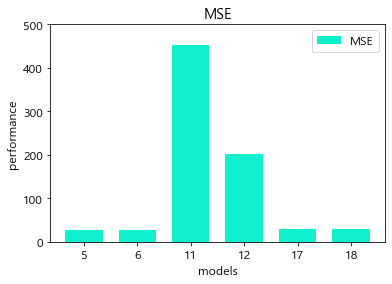

```python
%matplotlib inline

MSE = performance_3layer['MSE']

plt.rcParams['font.family'] = 'Malgun Gothic'
plt.rcParams['font.size'] = 12

plt.figure()

x = np.arange(len(index_3layer))

plt.bar(x-0.0, MSE, label='MSE', width=0.7, color='#0ff1ce')
plt.xticks(x, index_3layer)

plt.legend()
plt.xlabel('models')
plt.ylabel('performance')
plt.ylim(0, 500)
plt.title('MSE')

plt.show()

plt.close()
```

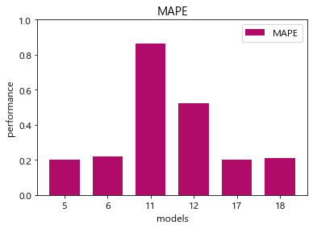

```python
%matplotlib inline

MAPE = performance_3layer['MAPE']

plt.rcParams['font.family'] = 'Malgun Gothic'
plt.rcParams['font.size'] = 12

plt.figure()

x = np.arange(len(index_3layer))

plt.bar(x-0.0, MAPE, label='MAPE', width=0.7, color='#b00b69')
plt.xticks(x, index_3layer)

plt.legend()
plt.xlabel('models')
plt.ylabel('performance')
plt.ylim(0, 1)
plt.title('MAPE')

plt.show()

plt.close()
```

## 각 layer별 최적 모델간의 비교

```python
performance_best = performance.loc[['4', '5', '7'],:]
index_best = ['4', '5', '7']
```

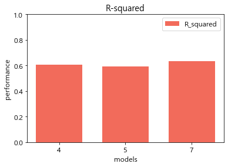

```python
%matplotlib inline

R_squared = performance_best['R_squared']

plt.rcParams['font.family'] = 'Malgun Gothic'
plt.rcParams['font.size'] = 12

plt.figure()

x = np.arange(len(index_best))

plt.bar(x-0.0, R_squared, label='R_squared', width=0.7, color='#f26b5b')
plt.xticks(x, index_best)

plt.legend()
plt.xlabel('models')
plt.ylabel('performance')
plt.ylim(0, 1)
plt.title('R-squared')

plt.show()

plt.close()
```

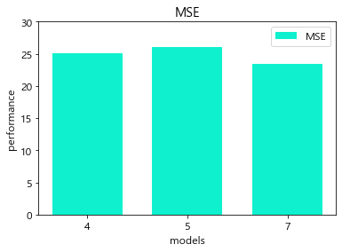

```python
%matplotlib inline

MSE = performance_best['MSE']

plt.rcParams['font.family'] = 'Malgun Gothic'
plt.rcParams['font.size'] = 12

plt.figure()

x = np.arange(len(index_best))

plt.bar(x-0.0, MSE, label='MSE', width=0.7, color='#0ff1ce')
plt.xticks(x, index_best)

plt.legend()
plt.xlabel('models')
plt.ylabel('performance')
plt.ylim(0, 30)
plt.title('MSE')

plt.show()

plt.close()
```

```
No handles with labels found to put in legend.
```

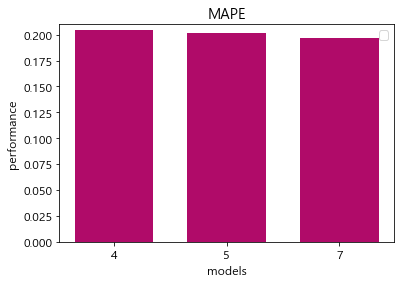

```python
%matplotlib inline

MAPE = performance_best['MAPE']

plt.rcParams['font.family'] = 'Malgun Gothic'
plt.rcParams['font.size'] = 12

plt.figure()

x = np.arange(len(index_best))

plt.bar(x-0.0, MAPE, width=0.7, color='#b00b69')  # label='MAPE',
plt.xticks(x, index_best)

plt.legend()
plt.xlabel('models')
plt.ylabel('performance')
plt.ylim(0, 0.21)
plt.title('MAPE')

plt.show()

plt.close()
```